# Questions

### Visualization of PCA projection with PCA: 2 first principal components

```python
def display_factorial_planes(X_projected, n_comp, pca, axis_ranks, labels=None, alpha=1, illustrative_var=None):
    '''Display a scatter plot on a factorial plane, one for each factorial plane'''

    # For each factorial plane
    for d1,d2 in axis_ranks:
        if d2 < n_comp:

            # Initialise the matplotlib figure
            fig = plt.figure(figsize=(7,6))

            # Display the points
            if illustrative_var is None:
                plt.scatter(X_projected[:, d1], X_projected[:, d2], alpha=alpha, cmap=color_palette('tab10'))
            else:
                illustrative_var = np.array(illustrative_var)
                for value in np.unique(illustrative_var):
                    selected = np.where(illustrative_var == value)
                    plt.scatter(X_projected[selected, d1], X_projected[selected, d2], alpha=alpha, label=value, cmap=color_palette('tab10'))
                plt.legend()

            # Display the labels on the points
            if labels is not None:
                for i,(x,y) in enumerate(X_projected[:,[d1,d2]]):
                    plt.text(x, y, labels[i],
                              fontsize='14', ha='center',va='center')

            # Define the limits of the chart
            boundary = np.max(np.abs(X_projected[:, [d1,d2]])) * 1.1
            plt.xlim([-boundary,boundary])
            plt.ylim([-boundary,boundary])

            # Display grid lines
            plt.plot([-100, 100], [0, 0], color='grey', ls='--')
            plt.plot([0, 0], [-100, 100], color='grey', ls='--')

            # Label the axes, with the percentage of variance explained
            plt.xlabel('PC{} ({}%)'.format(d1+1, round(100*pca.explained_variance_ratio_[d1],1)))
            plt.ylabel('PC{} ({}%)'.format(d2+1, round(100*pca.explained_variance_ratio_[d2],1)))

            plt.title("Projection of points (on PC{} and PC{})".format(d1+1, d2+1))
            #plt.show(block=False)
```

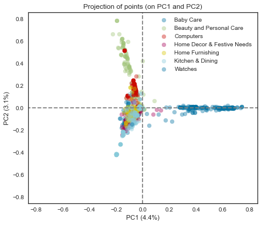

```python
display_factorial_planes(example_pca_trans, 5, pca, [(0,1)], illustrative_var = descri.general_category, alpha = 0.4)
# plt.savefig(savepath+'projection_pc1_pc2', bbox_inches='tight')
```

Conclusion: visualisation with PCA provides a poor quality. I have to try t-SNE (or Isomap).

### Visualization of PCA projection with t-SNE

[output not shown]

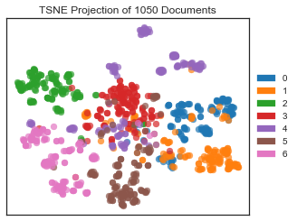

```python
tsne_vis = TSNEVisualizer(
#     decompose='svd',
#     decompose='pca', # TypeError: PCA does not support sparse input. See TruncatedSVD for a possible alternative.
    decompose=None,
    perplexity=15,
    colors=color_palette('tab10'),
    color=color_palette('tab20'),
    c=color_palette('tab20'),
#     colors=[plt.cm.Set3(i) for i in range(12)],
    init='random',
    learning_rate='auto')
tsne_vis.fit(example_pca_trans, orig_labels)
tsne_vis.show()
```

### Pipeline with dimensionality reduction made with PCA

#### Metrics:

Given the knowledge of the ground truth class assignments _labels*true*, Adjusted Rand index is a function that measures the similarity of the two assignments. A **higher Adjusted Rand index** relates to a model with higher similarity.

Same for other ground truth demanding scores: **higher value is better.**

If the ground truth labels are not known, Silhouette Coefficient is OK. A **higher Silhouette Coefficient** score relates to a model with better defined clusters.

If the ground truth labels are not known, Davies-Bouldin index is OK. A **lower Davies-Bouldin index** relates to a model with better separation between the clusters

If the ground truth labels are not known, the Calinski-Harabasz index is OK. A **higher Calinski-Harabasz score** relates to a model with better defined clusters.

```python
def pca_pipeline(name_series, name_vectorizer, myn_clusters=7, my_pca_compo=400, my_cumu_vari=0.95, comparison=True, pictures=False):
    myseries = descri[name_series]
    myvectorizer = eval(name_vectorizer)
    redu_spa, redu_arr = vectorize_pdseries(myseries, myvectorizer)
#     redu_arr = StandardScaler().fit_transform(redu_arr)
    print(redu_arr.shape, end='\t')

    pca = PCA(n_components=my_cumu_vari)
    trans_arr = pca.fit_transform(redu_arr)
    cumu_vari = pca.explained_variance_ratio_.cumsum()
#     print('Explained variance in {} components: {:.2f}'.format(my_pca_compo, cumu_vari[my_pca_compo]))  # for fixed number of components; for lemma_pos stemmer and tf_idf vectorizer it's 9%, 74%, 80.2% et 91% respectively
    print('Explained {} variance in {} components'.format(my_cumu_vari, cumu_vari.shape[0]))
    redu_arr = trans_arr
#     redu_arr = trans_arr[:, :my_pca_compo]
#     print('dataset shape after PCA: {}, first line length after PCA: {}'.format(redu_arr.shape, redu_arr[0].shape))

# #     if pictures:
# #         # original labels tSNEvis: with yellowbrick library
# #         tsne_vis_orig = TSNEVisualizer(decompose=None, perplexity=20, colors=color_palette('tab20'))
# #         # decompose='svd',  decompose='pca', colors=[plt.cm.Set3(i) for i in range(12)]
# #         # when X = redu_spa and decompose='pca', TypeError: PCA does not support sparse input. Use TruncatedSVD
# #         tsne_vis_orig.fit(redu_spa, orig_labels_names) # redu_spa for SVD or None decomposition method; redu_arr for PCA or None decomposition method
# #         tsne_vis_orig.show()

    if pictures:
        # original labels tSNEvis: with tSNE manifold and seaborn graph
        orig_tsne = manifold.TSNE(n_components=2, init='random', perplexity=20, learning_rate='auto') # init='pca' requires redu_arr
        X_trans = orig_tsne.fit_transform(redu_arr)  # init='pca' requires redu_arr
        X_df = pd.DataFrame(X_trans, columns=['dim1', 'dim2'])
        plt.figure()
        ax1 = scatterplot(x='dim1', y='dim2', data=X_df, hue=orig_labels_names, palette='tab10', alpha=0.5)


    # clustering with KMeans on text array
    myclust = cluster.KMeans(n_clusters=myn_clusters)
    myclust.fit(redu_arr) # also works with redu_arr, with the same result
    kmeans_labels = myclust.labels_
    if pictures:
        print('Cluster sizes \n{}'.format(pd.Series(kmeans_labels).value_counts())) # someties can be more than a half of all documents in 1 cluster


    # Metrics
    conf_mat = metrics.confusion_matrix(orig_labels, kmeans_labels)
    if comparison:
        metric_comparison.append(['PCA', 'notSNE', name_vectorizer, name_series,
               round(metrics.adjusted_rand_score(orig_labels, kmeans_labels), 3),
               round(metrics.adjusted_mutual_info_score(orig_labels, kmeans_labels), 3),
               round(metrics.homogeneity_score(orig_labels, kmeans_labels), 3),
               round(metrics.completeness_score(orig_labels, kmeans_labels), 3),
               round(metrics.fowlkes_mallows_score(orig_labels, kmeans_labels), 3),
               round(metrics.silhouette_score(redu_arr, kmeans_labels), 3),
               round(metrics.davies_bouldin_score(redu_arr, kmeans_labels), 3),  # TypeError: A sparse matrix was passed, but dense data is required. Use X.toarray() to convert to a dense numpy array.
               round(metrics.calinski_harabasz_score(redu_arr, kmeans_labels), 3)]) # TypeError: A sparse matrix was passed, but dense data is required. Use X.toarray() to convert to a dense numpy array.


    if pictures:
        print('ARI of KMeans labels', metrics.adjusted_rand_score(orig_labels, kmeans_labels))
        print('AMutual Info score of KMeans labels', metrics.adjusted_mutual_info_score(orig_labels, kmeans_labels))
        print('Homogeneity score of KMeans labels', metrics.homogeneity_score(orig_labels, kmeans_labels))
        print('Completeness score of KMeans labels', metrics.completeness_score(orig_labels, kmeans_labels))
        print('Fowlkes Mallows score of KMeans labels', metrics.fowlkes_mallows_score(orig_labels, kmeans_labels))
        print('Silhouette score of KMeans labels', metrics.silhouette_score(redu_arr, kmeans_labels))
        print('Davies-Bouldin index of KMeans labels', metrics.davies_bouldin_score(redu_arr, kmeans_labels)) # when use redu_spa, TypeError: A sparse matrix was passed, but dense data is required. Use X.toarray() to convert to a dense numpy array.
        print('Calinski-Harabasz score of KMeans labels', metrics.calinski_harabasz_score(redu_arr, kmeans_labels)) # when use redu_spa, TypeError: A sparse matrix was passed, but dense data is required. Use X.toarray() to convert to a dense numpy array.
# #       print(conf_mat)
# #       print(metrics.classification_report(orig_labels, my_labels))


# #     # KMeans labels tSNEvis: with yellowbrick library
# #     tsne_vis_kmeans = TSNEVisualizer(decompose=None, perplexity=20, colors=color_palette('tab20'))
# #     # decompose='svd',  decompose='pca', colors=[plt.cm.Set3(i) for i in range(12)]
# #     tsne_vis_kmeans.fit(redu_spa, my_labels) # redu_spa for SVD or None decomposition method; redu_arr # for use PCA or None decomposition method
# #     tsne_vis_kmeans.show()

    # KMeans labels tSNEvis: with tSNE manifold and seaborn graph
    myclust_tsne = manifold.TSNE(n_components=2, init='random', perplexity=20, learning_rate='auto') # init='pca' requires redu_arr
#     method='exact'
    X_trans = myclust_tsne.fit_transform(redu_arr) # init='pca' requires redu_arr
    X_df = pd.DataFrame(X_trans, columns=['dim1', 'dim2'])
    if pictures:
        plt.figure(figsize=(10,6))
        ax2 = scatterplot(x='dim1', y='dim2', data=X_df, hue=kmeans_labels, palette='tab10', alpha=0.5)
        plt.title('tSNEvis of KMeans clusters') #, fontsize = 30, pad = 35, fontweight = 'bold')
        plt.show()


    # draw a confusion matrix
    if pictures:
        df_cm = pd.DataFrame(conf_mat, index = [label for label in labels_names])
        plt.figure()
        ax3 = sns.heatmap(df_cm, annot=True, cmap='Blues', fmt='g')
        plt.show()


    # clustering with KMeans on tSNE projection
    cls_from_tsne = cluster.KMeans(n_clusters=7)
    cls_from_tsne.fit(X_trans)
    tsne_labels = cls_from_tsne.labels_
    if pictures:
        print('Cluster sizes \n{}'.format(pd.Series(tsne_labels).value_counts())) # someties can be more than a half of all documents in 1 cluster

    # Metrics
    conf_mat = metrics.confusion_matrix(orig_labels, tsne_labels)
    if comparison:
        metric_comparison.append(['PCA', 'tSNE', name_vectorizer, name_series,
               round(metrics.adjusted_rand_score(orig_labels, tsne_labels), 3),
               round(metrics.adjusted_mutual_info_score(orig_labels, tsne_labels), 3),
               round(metrics.homogeneity_score(orig_labels, tsne_labels), 3),
               round(metrics.completeness_score(orig_labels, tsne_labels), 3),
               round(metrics.fowlkes_mallows_score(orig_labels, tsne_labels), 3),
               round(metrics.silhouette_score(redu_arr, tsne_labels), 3),
               round(metrics.davies_bouldin_score(redu_arr, tsne_labels), 3),  # TypeError: A sparse matrix was passed, but dense data is required. Use X.toarray() to convert to a dense numpy array.
               round(metrics.calinski_harabasz_score(redu_arr, tsne_labels), 3)]) # TypeError: A sparse matrix was passed, but dense data is required. Use X.toarray() to convert to a dense numpy array.
    if pictures:
        print('ARI of labels from tSNE', metrics.adjusted_rand_score(orig_labels, tsne_labels))
        print('AMutual Info score of labels from tSNE', metrics.adjusted_mutual_info_score(orig_labels, tsne_labels))
        print('Homogeneity score of labels from tSNE', metrics.homogeneity_score(orig_labels, tsne_labels))
        print('Completeness score of labels from tSNE', metrics.completeness_score(orig_labels, tsne_labels))
        print('Fowlkes Mallows score of labels from tSNE', metrics.fowlkes_mallows_score(orig_labels, tsne_labels))
        print('Silhouette score of labels from tSNE', metrics.silhouette_score(redu_arr, tsne_labels))
        print('Davies-Bouldin index of labels from tSNE', metrics.davies_bouldin_score(redu_arr, tsne_labels)) # when use redu_spa, TypeError: A sparse matrix was passed, but dense data is required. Use X.toarray() to convert to a dense numpy array.
        print('Calinski-Harabasz score of labels from tSNE', metrics.calinski_harabasz_score(redu_arr, tsne_labels)) # when use redu_spa, TypeError: A sparse matrix was passed, but dense data is required. Use X.toarray() to convert to a dense numpy array.
# #       print(conf_mat)
# #       print(metrics.classification_report(orig_labels, my_labels))


#   tSNEvis of clusters BASED ON tSNE PROJECTION
    if pictures:
        plt.figure(figsize=(10,6))
        ax4 = sns.scatterplot(x='dim1', y='dim2', data=X_df, hue=tsne_labels, palette='tab10', alpha=0.5)
    #     hue='cl_lab'
        plt.title('TSNEvis of clusters based on tSNE') #, fontsize = 30, pad = 35, fontweight = 'bold')
    #     plt.xlabel('tsne1', fontsize = 26, fontweight = 'bold')
    #     plt.ylabel('tsne2', fontsize = 26, fontweight = 'bold')
    #     plt.legend(prop={'size': 14})
        plt.show()

    # draw a confusion matrix
    if pictures:
        df_cm = pd.DataFrame(conf_mat, index = [label for label in labels_names])
        plt.figure()
        ax3 = sns.heatmap(df_cm, annot=True, cmap='Blues', fmt='g')
        plt.show()
    return None
```

```python
# for vectoriz in ['count_vectorizer', 'tf_l1', 'tfidf_l2', 'tfidf_l2_bigrams']:
for vectoriz in ['count_vectorizer', 'tf_l1', 'tfidf_l2']: # bigrams isn't in the list of champions, not for any metric
#     for stem_lemma in descri.columns[8:]:
    for stem_lemma in ['token', 'porter', 'lancaster', 'lemma', 'lemma_pos']:
        pca_pipeline(stem_lemma, vectoriz)
print(descri.columns[8:])
```

```
(1050, 584)	Explained 0.95 variance in 150 components
(1050, 577)	Explained 0.95 variance in 153 components
(1050, 571)	Explained 0.95 variance in 155 components
(1050, 574)	Explained 0.95 variance in 149 components
(1050, 574)	Explained 0.95 variance in 149 components
(1050, 1157)	Explained 0.95 variance in 256 components
(1050, 1085)	Explained 0.95 variance in 256 components
(1050, 1063)	Explained 0.95 variance in 261 components
(1050, 1098)	Explained 0.95 variance in 255 components
(1050, 1088)	Explained 0.95 variance in 262 components
(1050, 1155)	Explained 0.95 variance in 386 components
(1050, 1083)	Explained 0.95 variance in 383 components
(1050, 1062)	Explained 0.95 variance in 383 components
(1050, 1096)	Explained 0.95 variance in 382 components
(1050, 1086)	Explained 0.95 variance in 384 components
Index(['image_fullpath', 'token', 'porter', 'lancaster', 'lemma', 'lemma_pos'], dtype='object')
```

#### Metrics:

Given the knowledge of the ground truth class assignments _labels*true*, Adjusted Rand index is a function that measures the similarity of the two assignments. A **higher Adjusted Rand index** relates to a model with higher similarity.

Same for other ground truth demanding scores: **higher value is better.**

If the ground truth labels are not known, Silhouette Coefficient is OK. A **higher Silhouette Coefficient** score relates to a model with better defined clusters.

If the ground truth labels are not known, Davies-Bouldin index is OK. A **lower Davies-Bouldin index** relates to a model with better separation between the clusters

If the ground truth labels are not known, the Calinski-Harabasz index is OK. A **higher Calinski-Harabasz score** relates to a model with better defined clusters.

```python
rating_full = pd.DataFrame(metric_comparison, columns=['Reduction', 'Projection', 'Vectorizer', 'StemLem',
        'ARI', 'AMII', 'Homo', 'Comple', 'Fowlkes', 'Silho', 'Bouldin', 'Harabasz'])

# rating_full.iloc[30:60, 0] = 'PCA'
rating_full.Bouldin = rating_full.Bouldin * -1
```

```python
rating_full.Reduction.value_counts()
```

```
greedy    30
PCA       30
Name: Reduction, dtype: int64
```

```python
rating_pca = rating_full[rating_full.Reduction == 'PCA']
```

```python
for metric in rating_pca.columns[4:]:
    print(metric, end=' ')
    display(rating_pca.sort_values(by=metric, ascending=False).head(2))
```

```
ARI
```

|  | Reduction | Projection | Vectorizer | StemLem | ARI | AMII | Homo | Comple | Fowlkes | Silho | Bouldin | Harabasz |
| --- | --- | --- | --- | --- | --- | --- | --- | --- | --- | --- | --- | --- |
| 51 | PCA | tSNE | tfidf_l2 | token | 0.590 | 0.670 | 0.668 | 0.677 | 0.650 | 0.066 | -4.573 | 23.389 |
| 55 | PCA | tSNE | tfidf_l2 | lancaster | 0.548 | 0.637 | 0.635 | 0.645 | 0.614 | 0.070 | -4.312 | 24.969 |

```
AMII
```

|  | Reduction | Projection | Vectorizer | StemLem | ARI | AMII | Homo | Comple | Fowlkes | Silho | Bouldin | Harabasz |
| --- | --- | --- | --- | --- | --- | --- | --- | --- | --- | --- | --- | --- |
| 51 | PCA | tSNE | tfidf_l2 | token | 0.590 | 0.670 | 0.668 | 0.677 | 0.650 | 0.066 | -4.573 | 23.389 |
| 55 | PCA | tSNE | tfidf_l2 | lancaster | 0.548 | 0.637 | 0.635 | 0.645 | 0.614 | 0.070 | -4.312 | 24.969 |

```
Homo
```

|  | Reduction | Projection | Vectorizer | StemLem | ARI | AMII | Homo | Comple | Fowlkes | Silho | Bouldin | Harabasz |
| --- | --- | --- | --- | --- | --- | --- | --- | --- | --- | --- | --- | --- |
| 51 | PCA | tSNE | tfidf_l2 | token | 0.590 | 0.670 | 0.668 | 0.677 | 0.650 | 0.066 | -4.573 | 23.389 |
| 55 | PCA | tSNE | tfidf_l2 | lancaster | 0.548 | 0.637 | 0.635 | 0.645 | 0.614 | 0.070 | -4.312 | 24.969 |

```
Comple
```

|  | Reduction | Projection | Vectorizer | StemLem | ARI | AMII | Homo | Comple | Fowlkes | Silho | Bouldin | Harabasz |
| --- | --- | --- | --- | --- | --- | --- | --- | --- | --- | --- | --- | --- |
| 51 | PCA | tSNE | tfidf_l2 | token | 0.590 | 0.670 | 0.668 | 0.677 | 0.650 | 0.066 | -4.573 | 23.389 |
| 55 | PCA | tSNE | tfidf_l2 | lancaster | 0.548 | 0.637 | 0.635 | 0.645 | 0.614 | 0.070 | -4.312 | 24.969 |

```
Fowlkes
```

|  | Reduction | Projection | Vectorizer | StemLem | ARI | AMII | Homo | Comple | Fowlkes | Silho | Bouldin | Harabasz |
| --- | --- | --- | --- | --- | --- | --- | --- | --- | --- | --- | --- | --- |
| 51 | PCA | tSNE | tfidf_l2 | token | 0.590 | 0.670 | 0.668 | 0.677 | 0.650 | 0.066 | -4.573 | 23.389 |
| 55 | PCA | tSNE | tfidf_l2 | lancaster | 0.548 | 0.637 | 0.635 | 0.645 | 0.614 | 0.070 | -4.312 | 24.969 |

```
Silho
```

|  | Reduction | Projection | Vectorizer | StemLem | ARI | AMII | Homo | Comple | Fowlkes | Silho | Bouldin | Harabasz |
| --- | --- | --- | --- | --- | --- | --- | --- | --- | --- | --- | --- | --- |
| 36 | PCA | notSNE | count_vectorizer | lemma | 0.012 | 0.105 | 0.080 | 0.226 | 0.324 | 0.499 | -1.431 | 95.334 |
| 38 | PCA | notSNE | count_vectorizer | lemma_pos | 0.011 | 0.080 | 0.065 | 0.160 | 0.310 | 0.472 | -1.918 | 95.890 |

```
Bouldin
```

|  | Reduction | Projection | Vectorizer | StemLem | ARI | AMII | Homo | Comple | Fowlkes | Silho | Bouldin | Harabasz |
| --- | --- | --- | --- | --- | --- | --- | --- | --- | --- | --- | --- | --- |
| 36 | PCA | notSNE | count_vectorizer | lemma | 0.012 | 0.105 | 0.08 | 0.226 | 0.324 | 0.499 | -1.431 | 95.334 |
| 30 | PCA | notSNE | count_vectorizer | token | 0.038 | 0.178 | 0.14 | 0.291 | 0.319 | 0.333 | -1.756 | 93.846 |

```
Harabasz
```

|  | Reduction | Projection | Vectorizer | StemLem | ARI | AMII | Homo | Comple | Fowlkes | Silho | Bouldin | Harabasz |
| --- | --- | --- | --- | --- | --- | --- | --- | --- | --- | --- | --- | --- |
| 38 | PCA | notSNE | count_vectorizer | lemma_pos | 0.011 | 0.080 | 0.065 | 0.160 | 0.310 | 0.472 | -1.918 | 95.890 |
| 36 | PCA | notSNE | count_vectorizer | lemma | 0.012 | 0.105 | 0.080 | 0.226 | 0.324 | 0.499 | -1.431 | 95.334 |

```python
for metric in rating_full.columns[4:]:
    print(metric, end=' ')
    display(rating_full.sort_values(by=metric, ascending=False).head(2))
```

```
ARI
```

|  | Reduction | Projection | Vectorizer | StemLem | ARI | AMII | Homo | Comple | Fowlkes | Silho | Bouldin | Harabasz |
| --- | --- | --- | --- | --- | --- | --- | --- | --- | --- | --- | --- | --- |
| 51 | PCA | tSNE | tfidf_l2 | token | 0.59 | 0.67 | 0.668 | 0.677 | 0.650 | 0.066 | -4.573 | 23.389 |
| 29 | greedy | tSNE | greedy_tf_idf | lemma_pos | 0.57 | 0.61 | 0.610 | 0.617 | 0.633 | 0.097 | -3.621 | 34.980 |

```
AMII
```

|  | Reduction | Projection | Vectorizer | StemLem | ARI | AMII | Homo | Comple | Fowlkes | Silho | Bouldin | Harabasz |
| --- | --- | --- | --- | --- | --- | --- | --- | --- | --- | --- | --- | --- |
| 51 | PCA | tSNE | tfidf_l2 | token | 0.590 | 0.670 | 0.668 | 0.677 | 0.650 | 0.066 | -4.573 | 23.389 |
| 55 | PCA | tSNE | tfidf_l2 | lancaster | 0.548 | 0.637 | 0.635 | 0.645 | 0.614 | 0.070 | -4.312 | 24.969 |

```
Homo
```

|  | Reduction | Projection | Vectorizer | StemLem | ARI | AMII | Homo | Comple | Fowlkes | Silho | Bouldin | Harabasz |
| --- | --- | --- | --- | --- | --- | --- | --- | --- | --- | --- | --- | --- |
| 51 | PCA | tSNE | tfidf_l2 | token | 0.590 | 0.670 | 0.668 | 0.677 | 0.650 | 0.066 | -4.573 | 23.389 |
| 55 | PCA | tSNE | tfidf_l2 | lancaster | 0.548 | 0.637 | 0.635 | 0.645 | 0.614 | 0.070 | -4.312 | 24.969 |

```
Comple
```

|  | Reduction | Projection | Vectorizer | StemLem | ARI | AMII | Homo | Comple | Fowlkes | Silho | Bouldin | Harabasz |
| --- | --- | --- | --- | --- | --- | --- | --- | --- | --- | --- | --- | --- |
| 51 | PCA | tSNE | tfidf_l2 | token | 0.590 | 0.670 | 0.668 | 0.677 | 0.650 | 0.066 | -4.573 | 23.389 |
| 55 | PCA | tSNE | tfidf_l2 | lancaster | 0.548 | 0.637 | 0.635 | 0.645 | 0.614 | 0.070 | -4.312 | 24.969 |

```
Fowlkes
```

|  | Reduction | Projection | Vectorizer | StemLem | ARI | AMII | Homo | Comple | Fowlkes | Silho | Bouldin | Harabasz |
| --- | --- | --- | --- | --- | --- | --- | --- | --- | --- | --- | --- | --- |
| 51 | PCA | tSNE | tfidf_l2 | token | 0.59 | 0.67 | 0.668 | 0.677 | 0.650 | 0.066 | -4.573 | 23.389 |
| 29 | greedy | tSNE | greedy_tf_idf | lemma_pos | 0.57 | 0.61 | 0.610 | 0.617 | 0.633 | 0.097 | -3.621 | 34.980 |

```
Silho
```

|  | Reduction | Projection | Vectorizer | StemLem | ARI | AMII | Homo | Comple | Fowlkes | Silho | Bouldin | Harabasz |
| --- | --- | --- | --- | --- | --- | --- | --- | --- | --- | --- | --- | --- |
| 36 | PCA | notSNE | count_vectorizer | lemma | 0.012 | 0.105 | 0.080 | 0.226 | 0.324 | 0.499 | -1.431 | 95.334 |
| 38 | PCA | notSNE | count_vectorizer | lemma_pos | 0.011 | 0.080 | 0.065 | 0.160 | 0.310 | 0.472 | -1.918 | 95.890 |

```
Bouldin
```

|  | Reduction | Projection | Vectorizer | StemLem | ARI | AMII | Homo | Comple | Fowlkes | Silho | Bouldin | Harabasz |
| --- | --- | --- | --- | --- | --- | --- | --- | --- | --- | --- | --- | --- |
| 12 | greedy | notSNE | greedy_tf | porter | 0.047 | 0.283 | 0.211 | 0.480 | 0.345 | 0.279 | -1.083 | 112.32 |
| 18 | greedy | notSNE | greedy_tf | lemma_pos | 0.135 | 0.424 | 0.338 | 0.595 | 0.390 | 0.240 | -1.152 | 122.63 |

```
Harabasz
```

|  | Reduction | Projection | Vectorizer | StemLem | ARI | AMII | Homo | Comple | Fowlkes | Silho | Bouldin | Harabasz |
| --- | --- | --- | --- | --- | --- | --- | --- | --- | --- | --- | --- | --- |
| 16 | greedy | notSNE | greedy_tf | lemma | 0.150 | 0.413 | 0.354 | 0.514 | 0.369 | 0.238 | -1.981 | 128.697 |
| 18 | greedy | notSNE | greedy_tf | lemma_pos | 0.135 | 0.424 | 0.338 | 0.595 | 0.390 | 0.240 | -1.152 | 122.630 |

```
(1050, 1155)	Explained 0.95 variance in 386 components
Cluster sizes
5    453
4    155
2    143
3     80
0     79
1     76
6     64
dtype: int64
ARI of KMeans labels 0.26927900393699256
AMutual Info score of KMeans labels 0.5017343647345042
Homogeneity score of KMeans labels 0.4703685568351107
Completeness score of KMeans labels 0.5487369934030009
Fowlkes Mallows score of KMeans labels 0.41616195780781556
Silhouette score of KMeans labels 0.06951916862287988
Davies-Bouldin index of KMeans labels 4.055913525059735
Calinski-Harabasz score of KMeans labels 27.844466156156404
```

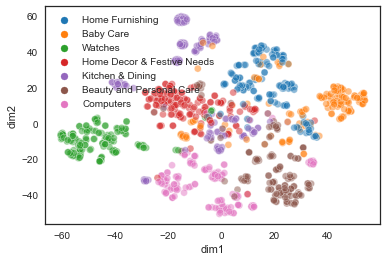

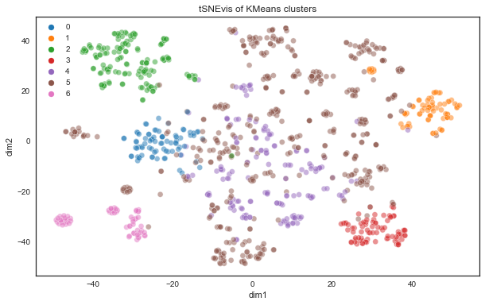

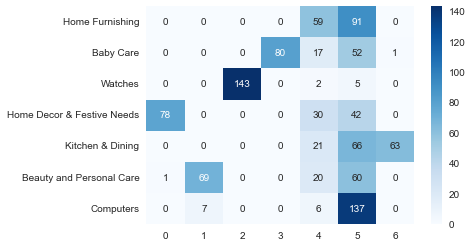

```
Cluster sizes
3    238
0    162
1    157
4    151
5    134
2    131
6     77
dtype: int64
ARI of labels from tSNE 0.5782690517955259
AMutual Info score of labels from tSNE 0.6581123107447088
Homogeneity score of labels from tSNE 0.6537034937002792
Completeness score of labels from tSNE 0.6688595815777063
Fowlkes Mallows score of labels from tSNE 0.641295875291028
Silhouette score of labels from tSNE 0.06637412099234288
Davies-Bouldin index of labels from tSNE 4.454408974878652
Calinski-Harabasz score of labels from tSNE 23.718641529980736
```

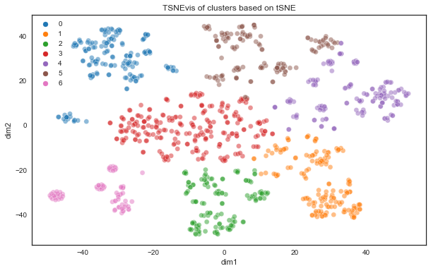

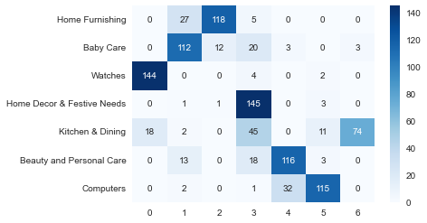

```python
# pca_pipeline('lemma_pos', 'tfidf_l2', comparison=False, pictures=True)
pca_pipeline('token', 'tfidf_l2', comparison=False, pictures=True)
```

## Dimensionality reduction made with Word2vec embeddings

Note: on pre-trained model Google News 300. The size of wocabulary is too small to train my own word embedding.

When you train a model on your own, the code (in the cell below) works, but the model gives low results.

The advantage is, you can load to the model as much of "out-of-vocabulary" words as you want, because there is no vocabulaty to be "out of". That means you can use not only unchanged words, as in Series "token", or lemmatized words, but also stemmed words. Even if they are not real words but stumps, the model takes them as given.

```python
# when you train a model on your own:
# test_model = Word2Vec(sentences=descri.token.values, vector_size=100, workers=1, seed=1)
```

### How many words are out of vocabulary for word2vec (NLTK Words corpus)

Before I found Google News 300, I thought to use NLTK Words corpus. It contains 235,892 unique words.

As I figured out later, it's impossible in any case to use NLTK Words corpus for Word2Vec, because there is no pre-trained neural network on this model.

```python
# print(len(set(nltk.corpus.words.words())))  # 235,892
# print(len(set(nltk.corpus.treebank.words())))  # 12,408
# print(len(set(nltk.corpus.brown.words())))  # 56,057
```

"Words" list is better than treebank, brown or whatever other list available in NLTK library.

```python
def non_nltk_corpus_words(text):
    text_vocab = set(w.lower() for w in text if w.isalpha())
    english_vocab = set(w.lower() for w in nltk.corpus.words.words())
    unusual = text_vocab.difference(english_vocab)
    return sorted(unusual), sorted(text_vocab)
```

```python
unus_w, vocab_w = non_nltk_corpus_words(test_w)
print('out-of-vocabulary words:{}, vocabulary size:{}, proportion of out-of-vocabulary words:{}'.format(len(unus_w),
        len(vocab_w), len(unus_w)/len(vocab_w)))

# print(unus_w) #there are normal words! such as:
# 'amplifies', 'amplifying', 'animals', 'annoying', 'anodised', 'anodized', 'ant', 'antimicrobial',
# 'anymore', 'anytime', 'aprons' etc
```

```
out-of-vocabulary words:1781, vocabulary size:4866, proportion of out-of-vocabulary words:0.3660090423345664
```

```python
# # # very similar results, 36.6% out of vocabulary, some correct words are marked as incorrect

unusu_wp, vocabu_wp = non_nltk_corpus_words(test_wp)
print('out-of-vocabulary words:{}, vocabulary size:{}, proportion of out-of-vocabulary words:{}'.format(len(unusu_wp),
        len(vocabu_wp), len(unusu_wp)/len(vocabu_wp)))

# unusu_wp #there are normal words! such as:
# 'amplifies', 'amplifying', 'animals', 'annoying', 'anodised', 'anodized', 'ant', 'antimicrobial',
# 'anymore', 'anytime', 'aprons'
```

```
out-of-vocabulary words:1787, vocabulary size:4876, proportion of out-of-vocabulary words:0.3664889253486464
```

For the Texts "test_regex" and "test_wp" the results are very close to those for test_w. We couldn't use a model where 36% of your words are out of vocabulary. An empiric threshold is 20%. You should have no more than 20% of out-of-your-vocabulry words to use a pre-trained model with that vocabulary.

### How many words are out of vocabulary for word2vec (Google News 300 corpus)

```python
time1 = time.time()
# model = Word2Vec.load_word2vec_format('GoogleNews-vectors-negative300.bin', binary=True, norm_only=True) # doesn't work
# wv = gensim.downloader.load('word2vec-google-news-300') # you can use this too if import the module without the alias
wv = api.load('word2vec-google-news-300')  #extremely long, like 20 minutes. next time though just 57 seconds.

print(f'database uploaded in {time.time() - time1} seconds.')
```

```
database uploaded in 75.17013454437256 seconds.
```

```python
word2vec_keys = wv.key_to_index.keys()
print(f'Google News 300 contains {len(word2vec_keys)} embeddings.')

word2vec_vocab = set(w.lower() for w in word2vec_keys)
print(f'Google News 300 contains {len(word2vec_vocab)} lowcase words.')
```

```
Google News 300 contains 3000000 embeddings.
Google News 300 contains 2702150 lowcase words.
```

```python
def non_word2vec_words(myseries):
    myvocab = set(' '.join(myseries.map(lambda x: ' '.join(x))).split())
    out_of_vocab = myvocab.difference(word2vec_vocab)
    return sorted(out_of_vocab), sorted(myvocab)
```

```python
token_out_of_vocab, token_vocab = non_word2vec_words(descri.token)
print(f'out-of-vocabulary words:{len(token_out_of_vocab)}, vocabulary size:{len(token_vocab)}, proportion of out-of-vocabulary words:{len(token_out_of_vocab)/len(token_vocab)}')

# print(token_out_of_vocab) # only weird words
```

```
out-of-vocabulary words:1386, vocabulary size:6120, proportion of out-of-vocabulary words:0.22647058823529412
```

```python
lemma_out_of_vocab, lemma_vocab = non_word2vec_words(descri.lemma)
print(f'out-of-vocabulary words:{len(lemma_out_of_vocab)}, vocabulary size:{len(lemma_vocab)}, proportion of out-of-vocabulary words:{len(lemma_out_of_vocab)/len(lemma_vocab)}')

# print(lemma_out_of_vocab) # only weird words
```

```
out-of-vocabulary words:1389, vocabulary size:5514, proportion of out-of-vocabulary words:0.25190424374319914
```

```python
lemma_pos_out_of_vocab, lemma_pos_vocab = non_word2vec_words(descri.lemma_pos)
print(f'out-of-vocabulary words:{len(lemma_pos_out_of_vocab)}, vocabulary size:{len(lemma_pos_vocab)}, proportion of out-of-vocabulary words:{len(lemma_pos_out_of_vocab)/len(lemma_pos_vocab)}')

# print(lemma_pos_out_of_vocab) # only weird words
```

```
out-of-vocabulary words:1388, vocabulary size:5509, proportion of out-of-vocabulary words:0.25195135233254673
```

Here it could be a good idea to remove rare words. And maybe also too frequent words, as vectorizer will not do it for us this time.

```python
def remove_hapaxes_and_too_frequent (my_series, low_limit=4, print_sizes=True):
    my_series_total_d = ' '.join(my_series.map(lambda x: ' '.join(x)))
    my_series_total_d = my_series_total_d.split()
    my_series_total_d = Text(my_series_total_d)
    my_series_fdist = nltk.FreqDist(my_series_total_d)
# this is the same as set min_df=2 in vectorizer, Count or TfIdf
    my_series_hapax = my_series_fdist.hapaxes() # shall I better remove words that occur less than 3 times ? less than 5 times?
#  this is the same as set min_df=3 in vectorizer, Count or TfIdf
    my_series_rare = [w for w in set(my_series_total_d) if my_series_fdist[w] < low_limit]
    my_series_between = [w for w in set(my_series_total_d) if my_series_fdist[w] > low_limit and my_series_fdist[w] < 350]

    if print_sizes:
        print('words number:', len(my_series_total_d), end='')
        print('; vocab length:', len(my_series_fdist), end='')

        print('; hapax number:', len(my_series_hapax), end='')
        print('; rare words number:', len(my_series_rare), end='')
        print('; excluded words number:', len(my_series_fdist) - len(my_series_between), end='')

        print('; vocab without hapaxes:', len(my_series_fdist) - len(my_series_hapax), end='')
        print('; vocab without rare words:', len(my_series_fdist) - len(my_series_rare), end='')
        print('; vocab without rare and frequent words:', len(my_series_between), ';')
#     return my_series.map(lambda x: [word for word in x if word not in my_series_hapax])
#     return my_series.map(lambda x: [word for word in x if word in my_series_lessthan])
    return my_series.map(lambda x: [word for word in x if word in my_series_between])
```

```python
token_out_of_vocab, token_vocab = non_word2vec_words(remove_hapaxes_and_too_frequent(descri.token, low_limit=3))
print(f'out-of-vocabulary words:{len(token_out_of_vocab)}, vocabulary size:{len(token_vocab)}, proportion of out-of-vocabulary words:{len(token_out_of_vocab)/len(token_vocab)}')

# print(token_out_of_vocab) # only weird words
```

```
words number: 79187; vocab length: 6120; hapax number: 1952; rare words number: 3277; excluded words number: 3906; vocab without hapaxes: 4168; vocab without rare words: 2843; vocab without rare and frequent words: 2214 ;
out-of-vocabulary words:293, vocabulary size:2214, proportion of out-of-vocabulary words:0.13233965672990064
```

```python
lemma_out_of_vocab, lemma_vocab = non_word2vec_words(remove_hapaxes_and_too_frequent(descri.lemma, low_limit=3))
print(f'out-of-vocabulary words:{len(lemma_out_of_vocab)}, vocabulary size:{len(lemma_vocab)}, proportion of out-of-vocabulary words:{len(lemma_out_of_vocab)/len(lemma_vocab)}')

# print(lemma_out_of_vocab) # only weird words
```

```
words number: 79187; vocab length: 5514; hapax number: 1726; rare words number: 2889; excluded words number: 3479; vocab without hapaxes: 3788; vocab without rare words: 2625; vocab without rare and frequent words: 2035 ;
out-of-vocabulary words:294, vocabulary size:2035, proportion of out-of-vocabulary words:0.14447174447174446
```

```python
lemma_pos_out_of_vocab, lemma_pos_vocab = non_word2vec_words(remove_hapaxes_and_too_frequent(descri.lemma_pos, low_limit=3))
print(f'out-of-vocabulary words:{len(lemma_pos_out_of_vocab)}, vocabulary size:{len(lemma_pos_vocab)}, proportion of out-of-vocabulary words:{len(lemma_pos_out_of_vocab)/len(lemma_pos_vocab)}')

# print(lemma_pos_out_of_vocab) # only weird words
```

```
words number: 79187; vocab length: 5509; hapax number: 1745; rare words number: 2903; excluded words number: 3488; vocab without hapaxes: 3764; vocab without rare words: 2606; vocab without rare and frequent words: 2021 ;
out-of-vocabulary words:294, vocabulary size:2021, proportion of out-of-vocabulary words:0.1454725383473528
```

```python
token_out_of_vocab, token_vocab = non_word2vec_words(remove_hapaxes_and_too_frequent(descri.token))
print(f'out-of-vocabulary words:{len(token_out_of_vocab)}, vocabulary size:{len(token_vocab)}, proportion of out-of-vocabulary words:{len(token_out_of_vocab)/len(token_vocab)}')

# print(token_out_of_vocab) # only weird words
```

```
words number: 79187; vocab length: 6120; hapax number: 1952; rare words number: 3874; excluded words number: 4323; vocab without hapaxes: 4168; vocab without rare words: 2246; vocab without rare and frequent words: 1797 ;
out-of-vocabulary words:203, vocabulary size:1797, proportion of out-of-vocabulary words:0.11296605453533667
```

```python
lemma_out_of_vocab, lemma_vocab = non_word2vec_words(remove_hapaxes_and_too_frequent(descri.lemma))
print(f'out-of-vocabulary words:{len(lemma_out_of_vocab)}, vocabulary size:{len(lemma_vocab)}, proportion of out-of-vocabulary words:{len(lemma_out_of_vocab)/len(lemma_vocab)}')

# print(lemma_out_of_vocab) # only weird words
```

```
words number: 79187; vocab length: 5514; hapax number: 1726; rare words number: 3443; excluded words number: 3845; vocab without hapaxes: 3788; vocab without rare words: 2071; vocab without rare and frequent words: 1669 ;
out-of-vocabulary words:204, vocabulary size:1669, proportion of out-of-vocabulary words:0.12222887956860395
```

```python
lemma_pos_out_of_vocab, lemma_pos_vocab = non_word2vec_words(remove_hapaxes_and_too_frequent(descri.lemma_pos))
print(f'out-of-vocabulary words:{len(lemma_pos_out_of_vocab)}, vocabulary size:{len(lemma_pos_vocab)}, proportion of out-of-vocabulary words:{len(lemma_pos_out_of_vocab)/len(lemma_pos_vocab)}')

# print(lemma_pos_out_of_vocab) # only weird words
```

```
words number: 79187; vocab length: 5509; hapax number: 1745; rare words number: 3452; excluded words number: 3867; vocab without hapaxes: 3764; vocab without rare words: 2057; vocab without rare and frequent words: 1642 ;
out-of-vocabulary words:204, vocabulary size:1642, proportion of out-of-vocabulary words:0.12423873325213154
```

```python
def mean_word_vectors(list_of_docs, model=wv):
    """Generate vectors for list of documents using a Word Embedding

    Args:
        list_of_docs: List of documents (or pd.Series.values, which is an array of lists)
        model: Gensim's Word Embedding

    Returns:
        List of document vectors
    """
    features = []

    for tokens in list_of_docs:
        zero_vector = np.zeros(model.vector_size)
        vectors = []
        for token in tokens:
            if token in wv:
                try:
                    vectors.append(wv[token])
                except KeyError:
                    continue
        if vectors:
            vectors = np.asarray(vectors)
            avg_vec = vectors.mean(axis=0)
            features.append(avg_vec)
        else:
            features.append(zero_vector)
    return features
```

```python
def word2vec_pipeline(name_series, myvectorizer=wv, myn_clusters=7, comparison=True, pictures=False):
    myseries = descri[name_series]
#     myseries = remove_hapaxes_and_too_frequent(myseries, low_limit=0, print_sizes=False)
#     myseries = remove_hapaxes_and_too_frequent(myseries, low_limit=3, print_sizes=False)
    myseries = remove_hapaxes_and_too_frequent(myseries, print_sizes=False)
    redu_arr = mean_word_vectors(myseries)
#     print(type(redu_arr), end=' ')
    redu_arr = np.asarray(redu_arr)
    print(redu_arr.shape, end='\t')

# #     if pictures:
# #         # original labels tSNEvis: with yellowbrick library
# #         tsne_vis_orig = TSNEVisualizer(decompose=None, perplexity=20, colors=color_palette('tab20'))
# #         # decompose='svd',  decompose='pca', colors=[plt.cm.Set3(i) for i in range(12)]
# #         # when X = redu_spa and decompose='pca', TypeError: PCA does not support sparse input. Use TruncatedSVD
# #         tsne_vis_orig.fit(redu_arr, orig_labels_names) # redu_spa for SVD or None decomposition method; redu_arr for PCA or None decomposition method
# #         tsne_vis_orig.show()

    if pictures:
        # original labels tSNEvis: with tSNE manifold and seaborn graph
        orig_tsne = manifold.TSNE(n_components=2, init='random', perplexity=20, learning_rate='auto') # init='pca' requires redu_arr
        X_trans = orig_tsne.fit_transform(redu_arr)  # init='pca' requires redu_arr
        X_df = pd.DataFrame(X_trans, columns=['dim1', 'dim2'])
        plt.figure()
        ax1 = scatterplot(x='dim1', y='dim2', data=X_df, hue=orig_labels_names, palette='tab10', alpha=0.5)


    # clustering with KMeans on text array
    myclust = cluster.KMeans(n_clusters=myn_clusters)
    myclust.fit(redu_arr) # also could work with redu_spa, if we had it here
    kmeans_labels = myclust.labels_
    if pictures:
        print('Cluster sizes \n{}'.format(pd.Series(kmeans_labels).value_counts())) # someties can be more than a half of all documents in 1 cluster

# #     # clustering with GaussianMixture on text array
#     mygaussian = GaussianMixture(n_components=myn_clusters)
#     mygaussian.fit(redu_arr)
# #     gaussian_labels = gaussian.predict(redu_arr) if tests show that Gaussian is better than KMeans
#     kmeans_labels = mygaussian.predict(redu_arr)
#     if pictures:
#         print('Cluster sizes \n{}'.format(pd.Series(kmeans_labels).value_counts())) # someties can be more than a half of all documents in 1 cluster



    # Metrics
    conf_mat = metrics.confusion_matrix(orig_labels, kmeans_labels)
    if comparison:
        metric_comparison.append(['Word2Vec', 'notSNE', 'pretrained_W2V', name_series,
               round(metrics.adjusted_rand_score(orig_labels, kmeans_labels), 3),
               round(metrics.adjusted_mutual_info_score(orig_labels, kmeans_labels), 3),
               round(metrics.homogeneity_score(orig_labels, kmeans_labels), 3),
               round(metrics.completeness_score(orig_labels, kmeans_labels), 3),
               round(metrics.fowlkes_mallows_score(orig_labels, kmeans_labels), 3),
               round(metrics.silhouette_score(redu_arr, kmeans_labels), 3),
               round(metrics.davies_bouldin_score(redu_arr, kmeans_labels), 3),  # TypeError: A sparse matrix was passed, but dense data is required. Use X.toarray() to convert to a dense numpy array.
               round(metrics.calinski_harabasz_score(redu_arr, kmeans_labels), 3)]) # TypeError: A sparse matrix was passed, but dense data is required. Use X.toarray() to convert to a dense numpy array.


    if pictures:
        print('ARI of KMeans labels', metrics.adjusted_rand_score(orig_labels, kmeans_labels))
        print('AMutual Info score of KMeans labels', metrics.adjusted_mutual_info_score(orig_labels, kmeans_labels))
        print('Homogeneity score of KMeans labels', metrics.homogeneity_score(orig_labels, kmeans_labels))
        print('Completeness score of KMeans labels', metrics.completeness_score(orig_labels, kmeans_labels))
        print('Fowlkes Mallows score of KMeans labels', metrics.fowlkes_mallows_score(orig_labels, kmeans_labels))
        print('Silhouette score of KMeans labels', metrics.silhouette_score(redu_arr, kmeans_labels))
        print('Davies-Bouldin index of KMeans labels', metrics.davies_bouldin_score(redu_arr, kmeans_labels)) # when use redu_spa, TypeError: A sparse matrix was passed, but dense data is required. Use X.toarray() to convert to a dense numpy array.
        print('Calinski-Harabasz score of KMeans labels', metrics.calinski_harabasz_score(redu_arr, kmeans_labels)) # when use redu_spa, TypeError: A sparse matrix was passed, but dense data is required. Use X.toarray() to convert to a dense numpy array.
# #       print(conf_mat)
# #       print(metrics.classification_report(orig_labels, my_labels))


# #     # KMeans labels tSNEvis: with yellowbrick library
# #     tsne_vis_kmeans = TSNEVisualizer(decompose=None, perplexity=20, colors=color_palette('tab20'))
# #     # decompose='svd',  decompose='pca', colors=[plt.cm.Set3(i) for i in range(12)]
# #     tsne_vis_kmeans.fit(redu_arr, my_labels) # redu_spa for SVD or None decomposition method; redu_arr # for use PCA or None decomposition method
# #     tsne_vis_kmeans.show()

    # KMeans labels tSNEvis: with tSNE manifold and seaborn graph
    myclust_tsne = manifold.TSNE(n_components=2, init='random', perplexity=20, learning_rate='auto') # init='pca' requires redu_arr
#     method='exact'
    X_trans = myclust_tsne.fit_transform(redu_arr) # init='pca' requires redu_arr
    X_df = pd.DataFrame(X_trans, columns=['dim1', 'dim2'])
    if pictures:
        plt.figure(figsize=(10,6))
        ax2 = scatterplot(x='dim1', y='dim2', data=X_df, hue=kmeans_labels, palette='tab10', alpha=0.5)
        plt.title('tSNEvis of KMeans clusters') #, fontsize = 30, pad = 35, fontweight = 'bold')
        plt.show()


    # draw a confusion matrix
    if pictures:
        df_cm = pd.DataFrame(conf_mat, index = [label for label in labels_names])
        plt.figure()
        ax3 = sns.heatmap(df_cm, annot=True, cmap='Blues', fmt='g')
        plt.show()


    # clustering with KMeans on tSNE projection
    cls_from_tsne = cluster.KMeans(n_clusters=7)
    cls_from_tsne.fit(X_trans)
    tsne_labels = cls_from_tsne.labels_
    if pictures:
        print('Cluster sizes \n{}'.format(pd.Series(tsne_labels).value_counts())) # someties can be more than a half of all documents in 1 cluster


#     #     # clustering with GaussianMixture on text array
#     gaussian_from_tsne = GaussianMixture(n_components=myn_clusters)
#     gaussian_from_tsne.fit(X_trans)
# #     gaussian_tsne_labels = gaussian.predict(redu_arr) if tests show that Gaussian is better than KMeans
#     tsne_labels = gaussian_from_tsne.predict(X_trans)
#     if pictures:
#         print('Cluster sizes \n{}'.format(pd.Series(tsne_labels).value_counts())) # someties can be more than a half of all documents in 1 cluster


    # Metrics
    conf_mat = metrics.confusion_matrix(orig_labels, tsne_labels)
    if comparison:
        metric_comparison.append(['Word2Vec', 'tSNE', 'pretrained_W2V', name_series,
               round(metrics.adjusted_rand_score(orig_labels, tsne_labels), 3),
               round(metrics.adjusted_mutual_info_score(orig_labels, tsne_labels), 3),
               round(metrics.homogeneity_score(orig_labels, tsne_labels), 3),
               round(metrics.completeness_score(orig_labels, tsne_labels), 3),
               round(metrics.fowlkes_mallows_score(orig_labels, tsne_labels), 3),
               round(metrics.silhouette_score(redu_arr, tsne_labels), 3),
               round(metrics.davies_bouldin_score(redu_arr, tsne_labels), 3),  # TypeError: A sparse matrix was passed, but dense data is required. Use X.toarray() to convert to a dense numpy array.
               round(metrics.calinski_harabasz_score(redu_arr, tsne_labels), 3)]) # TypeError: A sparse matrix was passed, but dense data is required. Use X.toarray() to convert to a dense numpy array.
    if pictures:
        print('ARI of labels from tSNE', metrics.adjusted_rand_score(orig_labels, tsne_labels))
        print('AMutual Info score of labels from tSNE', metrics.adjusted_mutual_info_score(orig_labels, tsne_labels))
        print('Homogeneity score of labels from tSNE', metrics.homogeneity_score(orig_labels, tsne_labels))
        print('Completeness score of labels from tSNE', metrics.completeness_score(orig_labels, tsne_labels))
        print('Fowlkes Mallows score of labels from tSNE', metrics.fowlkes_mallows_score(orig_labels, tsne_labels))
        print('Silhouette score of labels from tSNE', metrics.silhouette_score(redu_arr, tsne_labels))
        print('Davies-Bouldin index of labels from tSNE', metrics.davies_bouldin_score(redu_arr, tsne_labels)) # when use redu_spa, TypeError: A sparse matrix was passed, but dense data is required. Use X.toarray() to convert to a dense numpy array.
        print('Calinski-Harabasz score of labels from tSNE', metrics.calinski_harabasz_score(redu_arr, tsne_labels)) # when use redu_spa, TypeError: A sparse matrix was passed, but dense data is required. Use X.toarray() to convert to a dense numpy array.
# #       print(conf_mat)
# #       print(metrics.classification_report(orig_labels, my_labels))


#   tSNEvis of clusters BASED ON tSNE PROJECTION
    if pictures:
        plt.figure(figsize=(10,6))
        ax4 = sns.scatterplot(x='dim1', y='dim2', data=X_df, hue=tsne_labels, palette='tab10', alpha=0.5)
    #     hue='cl_lab'
        plt.title('TSNEvis of clusters based on tSNE') #, fontsize = 30, pad = 35, fontweight = 'bold')
    #     plt.xlabel('tsne1', fontsize = 26, fontweight = 'bold')
    #     plt.ylabel('tsne2', fontsize = 26, fontweight = 'bold')
    #     plt.legend(prop={'size': 14})
        plt.show()

    # draw a confusion matrix
    if pictures:
        df_cm = pd.DataFrame(conf_mat, index = [label for label in labels_names])
        plt.figure()
        ax3 = sns.heatmap(df_cm, annot=True, cmap='Blues', fmt='g')
        plt.show()
    return None
```

```python
for stem_lemma in ['token', 'lemma', 'lemma_pos']:
    word2vec_pipeline(stem_lemma)
```

```
(1050, 300)	(1050, 300)	(1050, 300)
```

#### Metrics:

Given the knowledge of the ground truth class assignments _labels*true*, Adjusted Rand index is a function that measures the similarity of the two assignments. A **higher Adjusted Rand index** relates to a model with higher similarity.

Same for other ground truth demanding scores: **higher value is better.**

If the ground truth labels are not known, Silhouette Coefficient is OK. A **higher Silhouette Coefficient** score relates to a model with better defined clusters.

If the ground truth labels are not known, Davies-Bouldin index is OK. A **lower Davies-Bouldin index** relates to a model with better separation between the clusters

If the ground truth labels are not known, the Calinski-Harabasz index is OK. A **higher Calinski-Harabasz score** relates to a model with better defined clusters.

```python
rating_full = pd.DataFrame(metric_comparison, columns=['Reduction', 'Projection', 'Vectorizer', 'StemLem',
        'ARI', 'AMII', 'Homo', 'Comple', 'Fowlkes', 'Silho', 'Bouldin', 'Harabasz'])

# rating_full.iloc[30:60, 0] = 'PCA'
rating_full.Bouldin = rating_full.Bouldin * -1
```

```python
rating_full.Reduction.value_counts()
```

```
greedy      30
PCA         30
Word2Vec     6
Name: Reduction, dtype: int64
```

```python
rating_w2v = rating_full[rating_full.Reduction == 'Word2Vec']
```

```python
for metric in rating_w2v.columns[4:]:
    print(metric, end=' ')
    display(rating_w2v.sort_values(by=metric, ascending=False).head(2))
```

```
ARI
```

|  | Reduction | Projection | Vectorizer | StemLem | ARI | AMII | Homo | Comple | Fowlkes | Silho | Bouldin | Harabasz |
| --- | --- | --- | --- | --- | --- | --- | --- | --- | --- | --- | --- | --- |
| 63 | Word2Vec | tSNE | pretrained_W2V | lemma | 0.507 | 0.594 | 0.596 | 0.600 | 0.578 | 0.010 | -3.141 | 43.371 |
| 61 | Word2Vec | tSNE | pretrained_W2V | token | 0.496 | 0.593 | 0.594 | 0.599 | 0.568 | 0.048 | -2.963 | 46.941 |

```
AMII
```

|  | Reduction | Projection | Vectorizer | StemLem | ARI | AMII | Homo | Comple | Fowlkes | Silho | Bouldin | Harabasz |
| --- | --- | --- | --- | --- | --- | --- | --- | --- | --- | --- | --- | --- |
| 63 | Word2Vec | tSNE | pretrained_W2V | lemma | 0.507 | 0.594 | 0.596 | 0.600 | 0.578 | 0.010 | -3.141 | 43.371 |
| 61 | Word2Vec | tSNE | pretrained_W2V | token | 0.496 | 0.593 | 0.594 | 0.599 | 0.568 | 0.048 | -2.963 | 46.941 |

```
Homo
```

|  | Reduction | Projection | Vectorizer | StemLem | ARI | AMII | Homo | Comple | Fowlkes | Silho | Bouldin | Harabasz |
| --- | --- | --- | --- | --- | --- | --- | --- | --- | --- | --- | --- | --- |
| 63 | Word2Vec | tSNE | pretrained_W2V | lemma | 0.507 | 0.594 | 0.596 | 0.600 | 0.578 | 0.010 | -3.141 | 43.371 |
| 61 | Word2Vec | tSNE | pretrained_W2V | token | 0.496 | 0.593 | 0.594 | 0.599 | 0.568 | 0.048 | -2.963 | 46.941 |

```
Comple
```

|  | Reduction | Projection | Vectorizer | StemLem | ARI | AMII | Homo | Comple | Fowlkes | Silho | Bouldin | Harabasz |
| --- | --- | --- | --- | --- | --- | --- | --- | --- | --- | --- | --- | --- |
| 63 | Word2Vec | tSNE | pretrained_W2V | lemma | 0.507 | 0.594 | 0.596 | 0.600 | 0.578 | 0.010 | -3.141 | 43.371 |
| 61 | Word2Vec | tSNE | pretrained_W2V | token | 0.496 | 0.593 | 0.594 | 0.599 | 0.568 | 0.048 | -2.963 | 46.941 |

```
Fowlkes
```

|  | Reduction | Projection | Vectorizer | StemLem | ARI | AMII | Homo | Comple | Fowlkes | Silho | Bouldin | Harabasz |
| --- | --- | --- | --- | --- | --- | --- | --- | --- | --- | --- | --- | --- |
| 63 | Word2Vec | tSNE | pretrained_W2V | lemma | 0.507 | 0.594 | 0.596 | 0.600 | 0.578 | 0.010 | -3.141 | 43.371 |
| 61 | Word2Vec | tSNE | pretrained_W2V | token | 0.496 | 0.593 | 0.594 | 0.599 | 0.568 | 0.048 | -2.963 | 46.941 |

```
Silho
```

|  | Reduction | Projection | Vectorizer | StemLem | ARI | AMII | Homo | Comple | Fowlkes | Silho | Bouldin | Harabasz |
| --- | --- | --- | --- | --- | --- | --- | --- | --- | --- | --- | --- | --- |
| 62 | Word2Vec | notSNE | pretrained_W2V | lemma | 0.168 | 0.446 | 0.382 | 0.551 | 0.381 | 0.182 | -1.949 | 74.824 |
| 60 | Word2Vec | notSNE | pretrained_W2V | token | 0.190 | 0.473 | 0.426 | 0.545 | 0.377 | 0.158 | -2.324 | 65.132 |

```
Bouldin
```

|  | Reduction | Projection | Vectorizer | StemLem | ARI | AMII | Homo | Comple | Fowlkes | Silho | Bouldin | Harabasz |
| --- | --- | --- | --- | --- | --- | --- | --- | --- | --- | --- | --- | --- |
| 62 | Word2Vec | notSNE | pretrained_W2V | lemma | 0.168 | 0.446 | 0.382 | 0.551 | 0.381 | 0.182 | -1.949 | 74.824 |
| 64 | Word2Vec | notSNE | pretrained_W2V | lemma_pos | 0.202 | 0.465 | 0.410 | 0.552 | 0.389 | 0.134 | -2.024 | 75.838 |

```
Harabasz
```

|  | Reduction | Projection | Vectorizer | StemLem | ARI | AMII | Homo | Comple | Fowlkes | Silho | Bouldin | Harabasz |
| --- | --- | --- | --- | --- | --- | --- | --- | --- | --- | --- | --- | --- |
| 64 | Word2Vec | notSNE | pretrained_W2V | lemma_pos | 0.202 | 0.465 | 0.410 | 0.552 | 0.389 | 0.134 | -2.024 | 75.838 |
| 62 | Word2Vec | notSNE | pretrained_W2V | lemma | 0.168 | 0.446 | 0.382 | 0.551 | 0.381 | 0.182 | -1.949 | 74.824 |

The champions inside W2V subgroup are (they do vary from launch to launch):

- lemma notSNE (Silhouette, Bouldin)
- lemma_pos notSNE (Harabasz)

```python
for metric in rating_full.columns[4:]:
    print(metric, end=' ')
    display(rating_full.sort_values(by=metric, ascending=False).head(2))
```

```
ARI
```

|  | Reduction | Projection | Vectorizer | StemLem | ARI | AMII | Homo | Comple | Fowlkes | Silho | Bouldin | Harabasz |
| --- | --- | --- | --- | --- | --- | --- | --- | --- | --- | --- | --- | --- |
| 51 | PCA | tSNE | tfidf_l2 | token | 0.59 | 0.67 | 0.668 | 0.677 | 0.650 | 0.066 | -4.573 | 23.389 |
| 29 | greedy | tSNE | greedy_tf_idf | lemma_pos | 0.57 | 0.61 | 0.610 | 0.617 | 0.633 | 0.097 | -3.621 | 34.980 |

```
AMII
```

|  | Reduction | Projection | Vectorizer | StemLem | ARI | AMII | Homo | Comple | Fowlkes | Silho | Bouldin | Harabasz |
| --- | --- | --- | --- | --- | --- | --- | --- | --- | --- | --- | --- | --- |
| 51 | PCA | tSNE | tfidf_l2 | token | 0.590 | 0.670 | 0.668 | 0.677 | 0.650 | 0.066 | -4.573 | 23.389 |
| 55 | PCA | tSNE | tfidf_l2 | lancaster | 0.548 | 0.637 | 0.635 | 0.645 | 0.614 | 0.070 | -4.312 | 24.969 |

```
Homo
```

|  | Reduction | Projection | Vectorizer | StemLem | ARI | AMII | Homo | Comple | Fowlkes | Silho | Bouldin | Harabasz |
| --- | --- | --- | --- | --- | --- | --- | --- | --- | --- | --- | --- | --- |
| 51 | PCA | tSNE | tfidf_l2 | token | 0.590 | 0.670 | 0.668 | 0.677 | 0.650 | 0.066 | -4.573 | 23.389 |
| 55 | PCA | tSNE | tfidf_l2 | lancaster | 0.548 | 0.637 | 0.635 | 0.645 | 0.614 | 0.070 | -4.312 | 24.969 |

```
Comple
```

|  | Reduction | Projection | Vectorizer | StemLem | ARI | AMII | Homo | Comple | Fowlkes | Silho | Bouldin | Harabasz |
| --- | --- | --- | --- | --- | --- | --- | --- | --- | --- | --- | --- | --- |
| 51 | PCA | tSNE | tfidf_l2 | token | 0.590 | 0.670 | 0.668 | 0.677 | 0.650 | 0.066 | -4.573 | 23.389 |
| 55 | PCA | tSNE | tfidf_l2 | lancaster | 0.548 | 0.637 | 0.635 | 0.645 | 0.614 | 0.070 | -4.312 | 24.969 |

```
Fowlkes
```

|  | Reduction | Projection | Vectorizer | StemLem | ARI | AMII | Homo | Comple | Fowlkes | Silho | Bouldin | Harabasz |
| --- | --- | --- | --- | --- | --- | --- | --- | --- | --- | --- | --- | --- |
| 51 | PCA | tSNE | tfidf_l2 | token | 0.59 | 0.67 | 0.668 | 0.677 | 0.650 | 0.066 | -4.573 | 23.389 |
| 29 | greedy | tSNE | greedy_tf_idf | lemma_pos | 0.57 | 0.61 | 0.610 | 0.617 | 0.633 | 0.097 | -3.621 | 34.980 |

```
Silho
```

|  | Reduction | Projection | Vectorizer | StemLem | ARI | AMII | Homo | Comple | Fowlkes | Silho | Bouldin | Harabasz |
| --- | --- | --- | --- | --- | --- | --- | --- | --- | --- | --- | --- | --- |
| 36 | PCA | notSNE | count_vectorizer | lemma | 0.012 | 0.105 | 0.080 | 0.226 | 0.324 | 0.499 | -1.431 | 95.334 |
| 38 | PCA | notSNE | count_vectorizer | lemma_pos | 0.011 | 0.080 | 0.065 | 0.160 | 0.310 | 0.472 | -1.918 | 95.890 |

```
Bouldin
```

|  | Reduction | Projection | Vectorizer | StemLem | ARI | AMII | Homo | Comple | Fowlkes | Silho | Bouldin | Harabasz |
| --- | --- | --- | --- | --- | --- | --- | --- | --- | --- | --- | --- | --- |
| 12 | greedy | notSNE | greedy_tf | porter | 0.047 | 0.283 | 0.211 | 0.480 | 0.345 | 0.279 | -1.083 | 112.32 |
| 18 | greedy | notSNE | greedy_tf | lemma_pos | 0.135 | 0.424 | 0.338 | 0.595 | 0.390 | 0.240 | -1.152 | 122.63 |

```
Harabasz
```

|  | Reduction | Projection | Vectorizer | StemLem | ARI | AMII | Homo | Comple | Fowlkes | Silho | Bouldin | Harabasz |
| --- | --- | --- | --- | --- | --- | --- | --- | --- | --- | --- | --- | --- |
| 16 | greedy | notSNE | greedy_tf | lemma | 0.150 | 0.413 | 0.354 | 0.514 | 0.369 | 0.238 | -1.981 | 128.697 |
| 18 | greedy | notSNE | greedy_tf | lemma_pos | 0.135 | 0.424 | 0.338 | 0.595 | 0.390 | 0.240 | -1.152 | 122.630 |

```
(1050, 300)	Cluster sizes
2    609
5    149
3    128
0     84
1     55
4     19
6      6
dtype: int64
ARI of KMeans labels 0.1607394212128492
AMutual Info score of KMeans labels 0.3995381557225291
Homogeneity score of KMeans labels 0.33969439308112276
Completeness score of KMeans labels 0.5052744243221823
Fowlkes Mallows score of KMeans labels 0.3756875965932742
Silhouette score of KMeans labels 0.17765679541155183
Davies-Bouldin index of KMeans labels 1.9605869260768558
Calinski-Harabasz score of KMeans labels 68.5944192258893
```

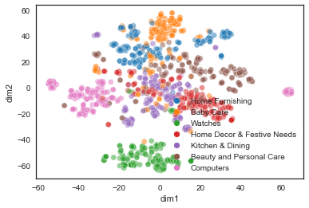

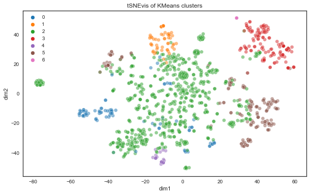

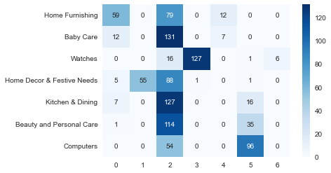

```
Cluster sizes
0    239
2    192
6    162
3    147
1    137
5    107
4     66
dtype: int64
ARI of labels from tSNE 0.5112540050313963
AMutual Info score of labels from tSNE 0.5958702167553446
Homogeneity score of labels from tSNE 0.5899272428563408
Completeness score of labels from tSNE 0.6094584724772809
Fowlkes Mallows score of labels from tSNE 0.5855841877226329
Silhouette score of labels from tSNE 0.028181138092873037
Davies-Bouldin index of labels from tSNE 2.9392098629187373
Calinski-Harabasz score of labels from tSNE 43.26602372835777
```

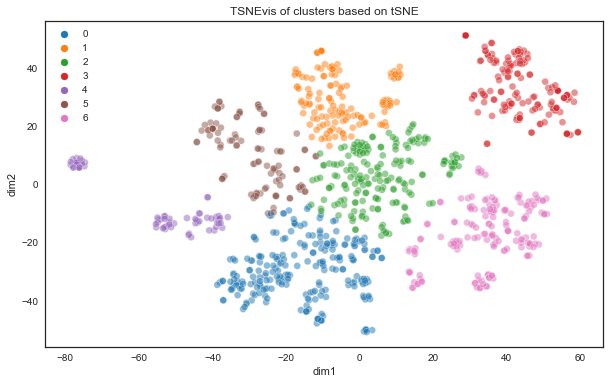

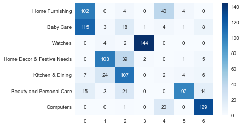

```python
word2vec_pipeline('lemma', comparison=False, pictures=True)
```

## Dimensionality reduction made with NMF

```python
NMF_spa, NMF_arr = vectorize_pdseries(descri.token, tfidf_l2) # <1050x1018 sparse matrix of type '<class 'numpy.float64'>' with 22572 stored elements in Compressed Sparse Row format>
print(type(NMF_spa), type(NMF_arr))
```

```
<class 'scipy.sparse.csr.csr_matrix'> <class 'numpy.ndarray'>
```

```python
nmf_model = NMF(n_components=7, init='random')
W = nmf_model.fit_transform(NMF_spa) # ValueError: setting an array element with a sequence
H = nmf_model.components_
err = nmf_model.reconstruction_err_
```

```python
W.shape
```

```
(1050, 7)
```

```python
# recover max probabiliry of a class
nmf_labels = ([np.argmax(docline) for docline in W])
```

```python
conf_mat = metrics.confusion_matrix(orig_labels, nmf_labels)
print('ARI of KMeans labels', metrics.adjusted_rand_score(orig_labels, nmf_labels))
print('AMutual Info score of KMeans labels', metrics.adjusted_mutual_info_score(orig_labels, nmf_labels))
print('Homogeneity score of KMeans labels', metrics.homogeneity_score(orig_labels, nmf_labels))
print('Completeness score of KMeans labels', metrics.completeness_score(orig_labels, nmf_labels))
print('Fowlkes Mallows score of KMeans labels', metrics.fowlkes_mallows_score(orig_labels, nmf_labels))
print('Silhouette score of KMeans labels', metrics.silhouette_score(W, nmf_labels))
print('Davies-Bouldin index of KMeans labels', metrics.davies_bouldin_score(W, nmf_labels)) # when use redu_spa, TypeError: A sparse matrix was passed, but dense data is required. Use X.toarray() to convert to a dense numpy array.
print('Calinski-Harabasz score of KMeans labels', metrics.calinski_harabasz_score(W, nmf_labels)) # when use redu_spa, TypeError: A sparse matrix was passed, but dense data is required. Use X.toarray() to convert to a dense numpy array.
```

```
ARI of KMeans labels 0.3090785988803499
AMutual Info score of KMeans labels 0.4790006454098617
Homogeneity score of KMeans labels 0.4670923062546303
Completeness score of KMeans labels 0.5017984145332678
Fowlkes Mallows score of KMeans labels 0.42226960142155145
Silhouette score of KMeans labels 0.3225993811003205
Davies-Bouldin index of KMeans labels 0.8675862763065874
Calinski-Harabasz score of KMeans labels 395.26308504282486
```

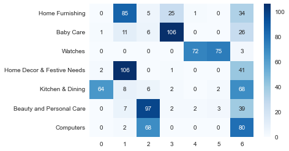

```python
df_cm = pd.DataFrame(conf_mat, index = [label for label in labels_names])
plt.figure()
ax3 = sns.heatmap(df_cm, annot=True, cmap='Blues', fmt='g')
plt.show()
```

```python
tsne = manifold.TSNE(n_components=2, perplexity=20, learning_rate='auto',
                     n_iter=2000, init='random')


nmf_tsne = tsne.fit_transform(W)

df_NMF = pd.DataFrame(nmf_tsne[:,0:2], columns=['tsne1', 'tsne2'])
print(df_NMF.shape)
```

```
(1050, 2)
```

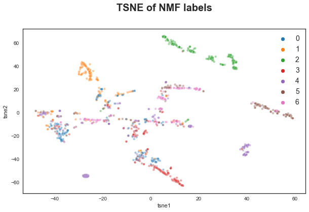

```python
plt.figure(figsize=(10,6))
sns.scatterplot(
    x='tsne1', y='tsne2',
    hue=orig_labels,
    palette=sns.color_palette('tab10', n_colors=7), s=20, alpha=0.4,
    data=df_NMF,
    legend='brief')

plt.title('TSNE of NMF labels', fontsize = 20, pad = 35, fontweight = 'bold')
# plt.xlabel('tsne1', fontsize=16, fontweight = 'bold')
# plt.ylabel('tsne2', fontsize=16, fontweight = 'bold')
plt.legend(prop={'size': 14})

plt.show()
```

```python
# %who_ls
```

```python
# del api, ax3, cate, cluster, color_palette, conf_mat, count_vectorizer, cumu_vari, decode_predictions, decomposition, defaultdict, df_NMF, df_cm, display_factorial_planes, empty_phrase, empty_phrases, end_time, err, example_arr, example_arr_st, example_pca_trans, example_spa, fdist_regex, fdist_w, fdist_wp, gluey_symbols, greedy_count, greedy_tf, greedy_tf_idf, greedy_tf_idf_bigrams, greedy_vectorizer_pipeline, i, img_to_array, keep_cols, lemma_out_of_vocab, lemma_pos_out_of_vocab, lemma_pos_vocab, lemma_vocab, lemmatizer, lemmatizer_multi, letters_long, letters_long_stopwords, letters_only, long_only, long_words_w, manifold, mean_word_vectors, metric, metric_comparison, metrics, my_stopwords, nltk, nmf_labels, nmf_model, nmf_tsne, no_stopwords, non_nltk_corpus_words, non_word2vec_words, orig_labels, orig_labels_names, palplot, pca, pca_pipeline, rating_full, rating_greedy, rating_pca, rating_w2v, regexp, remove_hapaxes_and_too_frequent, scatterplot, scree, set_style, sns, stem_lancaster, stem_lemma, stem_lemma1, stem_lemma2, stem_porter, stopwords, symb, tag_map, test_regex, test_w, test_wp, tf_l1, tfidf_l2, tfidf_l2_bigrams, token_out_of_vocab, token_vocab, total_description, tsne, tsne_vis, unus_w, unusu_wp, vectoriz, vectorize_pdseries, vocab_regex, vocab_w, vocab_wp, vocabu_wp, word2vec_keys, word2vec_pipeline, word2vec_vocab, wordnet, wordpunct, wv
```

# Synthesis of text and image

As we saw, the results on text are rather similar for greedy vectorizer, for PCA and for Word2Vec model. Sometimes one method of dimensionality reduction wins, sometimes another one.

But what I also observed, results for the text are stably better when clustering is applied on tSNE-projection. For the image, it seems to be the same outcome: tSNE projection is better.

That's why I will take a tSNE projection of the image dataset, combine it with the tSNE projection of a text, and run KMenas on resulting array. That will give the dataset of 4 dimensions. Let's see whether it will be better together than any of them single.

```python
redu_spa, redu_arr = vectorize_pdseries(descri.lemma_pos, greedy_tf_idf)
```

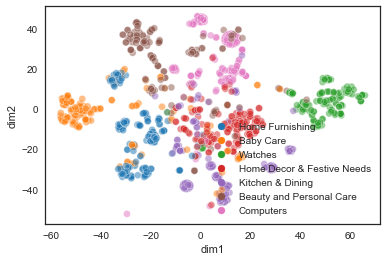

```python
# original labels tSNEvis: with tSNE manifold and seaborn graph
orig_tsne = manifold.TSNE(n_components=2, init='random', perplexity=20, learning_rate='auto') # init='pca' requires redu_arr
X_trans = orig_tsne.fit_transform(redu_arr)  # init='pca' requires redu_arr
X_df = pd.DataFrame(X_trans, columns=['dim1', 'dim2'])
plt.figure()
ax1 = scatterplot(x='dim1', y='dim2', data=X_df, hue=orig_labels_names, palette='tab10', alpha=0.5)
```

```python
# synthetic = np.concatenate((X_tsne, X_trans), axis=1)
# synthetic = np.concatenate((vgg16_full_trans_tsne, X_trans), axis=1)
synthetic = np.concatenate((vgg16_part_trans_tsne, X_trans), axis=1)

cls_synthetic = cluster.KMeans(n_clusters=7)
cls_synthetic.fit(synthetic)
synthetic_labels = cls_synthetic.labels_
print('Cluster sizes \n{}'.format(pd.Series(synthetic_labels).value_counts())) # someties can be more than a half of all documents in 1 cluster
```

```
Cluster sizes
0    251
6    177
5    148
2    144
4    128
1    117
3     85
dtype: int64
```

```python
print('ARI of labels from tSNE', metrics.adjusted_rand_score(orig_labels, synthetic_labels))
print('AMutual Info score of labels from tSNE', metrics.adjusted_mutual_info_score(orig_labels, synthetic_labels))
print('Homogeneity score of labels from tSNE', metrics.homogeneity_score(orig_labels, synthetic_labels))
print('Completeness score of labels from tSNE', metrics.completeness_score(orig_labels, synthetic_labels))
print('Fowlkes Mallows score of labels from tSNE', metrics.fowlkes_mallows_score(orig_labels, synthetic_labels))
print('Silhouette score of labels from tSNE', metrics.silhouette_score(redu_spa, synthetic_labels))
print('Davies-Bouldin index of labels from tSNE', metrics.davies_bouldin_score(redu_arr, synthetic_labels)) # when use redu_spa, TypeError: A sparse matrix was passed, but dense data is required. Use X.toarray() to convert to a dense numpy array.
print('Calinski-Harabasz score of labels from tSNE', metrics.calinski_harabasz_score(redu_arr, synthetic_labels)) # when use redu_spa, TypeError: A sparse matrix was passed, but dense data is required. Use X.toarray() to convert to a dense numpy array.
```

```
ARI of labels from tSNE 0.5984029354883568
AMutual Info score of labels from tSNE 0.6822574472949522
Homogeneity score of labels from tSNE 0.6762408449017997
Completeness score of labels from tSNE 0.6942495035529659
Fowlkes Mallows score of labels from tSNE 0.6592004382067118
Silhouette score of labels from tSNE 0.09352421573307214
Davies-Bouldin index of labels from tSNE 3.7308622992005773
Calinski-Harabasz score of labels from tSNE 34.90951521131481
```

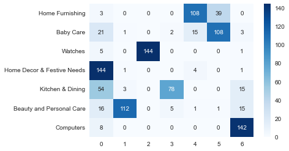

```python
conf_mat = metrics.confusion_matrix(orig_labels, synthetic_labels)

df_cm = pd.DataFrame(conf_mat, index = [label for label in labels_names])
plt.figure()
ax3 = sns.heatmap(df_cm, annot=True, cmap='Blues', fmt='g')
plt.show()
```

# Support code, code samples (will be removed from final project)

## Pretrained VGG-16 with dense layers removed

Disclaimer: this method cn be used only as a classification method! We need the sampes with the pre-defined labels to make a train set. And if we want to make evaluation, we need a test set apart.

At I will train the neural tenwork on all the 1050 images, then predict the probabilities on the same set. I now that this practice leads to overfitting, the results will be overestimated. But this is to see how to create transfer learning VGG16. In practice, the image sets for testing should be new, those that your model didn't see during training.

What I can do later - set aside about 50 images for the evaluation, to get the nuperic metrics. Then get the resulted vectors for all the 1050 images. I know that normally you mustn't make any predictions on the trained data.

I do it just to learn to work with VGG16 with recreating top layers.

```python
# from tensorflow.keras.utils import to_categorical
# from tensorflow.keras.applications.vgg16 import VGG16
# from tensorflow.keras.applications.vgg16 import preprocess_input
# from tensorflow.keras import layers, models
# from tensorflow.keras.callbacks import EarlyStopping
```

```python
# # ## Example: Resizing images
# # train_ds = tf.image.resize(train_ds, (150, 150))
# # test_ds = tf.image.resize(test_ds, (150, 150))

# # ## Example: Transforming labels to correct format
# # train_labels = to_categorical(train_labels, num_classes=5)
# # test_labels = to_categorical(test_labels, num_classes=5)

# VGG_labels = to_categorical(orig_labels, num_classes=7)
```

```python
# print(test2[0].shape) # convert image to array
# print(test3[0].shape) # envelop image, make a "collection of images" with 1 sample
# print(test4[0].shape) # preprocess input
# print(test5[0].shape) # predict the 1000 probabilities of 1000 classes with VGG16
# print(test6[0].shape) # remove the "envelop" / reshape the array


# # ## Loading VGG16 model
# # my_model = VGG16(weights="imagenet", include_top=False, input_shape=(224, 224, 3)) #from openclassrooms
# # base_model = VGG16(weights="imagenet", include_top=False, input_shape=test4[0].shape) # ValueError: `input_shape` must be a tuple of three integers
# base_model = VGG16(weights="imagenet", include_top=False, input_shape=test2[0].shape) # which is (224, 224, 3)

# # ## Preprocessing input
# test7 = preprocess_input(np.stack(test2.values))
```

```python
# flatten_layer = layers.Flatten()
# dense_layer_1 = layers.Dense(50, activation='relu')
# dense_layer_2 = layers.Dense(20, activation='relu')
# prediction_layer = layers.Dense(7, activation='softmax')

# flex_model = models.Sequential([
#     base_model,
#     flatten_layer,
#     dense_layer_1,
#     dense_layer_2,
#     prediction_layer
# ])

# flex_model.compile(
#     optimizer='adam',
#     loss='categorical_crossentropy',
#     metrics=['accuracy'],
# )
```

```python
# es = EarlyStopping(monitor='val_accuracy', mode='max', patience=5,  restore_best_weights=True)

# flex_model.fit(test7, VGG_labels, epochs=50, validation_split=0.2, batch_size=32, callbacks=[es])
```

```python
# time1 = time.time()
# test8 = test4.map(lambda x: flex_model.predict(x))
# print(f'prediction of 7 probabilities for 1050 images is done in {time.time() - time1} seconds.')
```

Then do the same operations as for the full network: predict (output is a vector of length 7, for our 7 groups), and select the class with max probability, make the index the label [argmax(x) for x in output], evaluate with metrics and visualize.

## Latent Dirichlet Allocation

```python
# n_categories = 7
# n_top_words = 10

# def display_topics(model, feature_names, n_top_words):
#     for topic_idx, topic in enumerate(model.components_):
#         print('Category {}:'.format(topic_idx))
#         print(' '.join([feature_names[i] for i in topic.argsort()[:-n_top_words - 1:-1]]))


# lda = LatentDirichletAllocation(
#         n_components=n_categories, # in the video n_topics = no_topics, after error correction n_topics=n_topics
#         max_iter=5,
#         learning_method='online',
#         learning_offset=50.)
# lda.fit(redu_arr)
# print(lda.components_.shape)

# display_topics(lda, regex_lemma_feature_names, n_top_words)
```

LDA is a bad classification at this step: I see router, wireless and lipstick in the same category

## Untrained VGG16, to train from scratch

```python
# # train your own neural network from scratch, based only on your own images

# from tensorflow.keras.models import Sequential
# from tensorflow.keras.layers import Conv2D, MaxPooling2D

# my_VGG16 = Sequential()  # Création d'un réseau de neurones vide

# # Ajout de la première couche de convolution, suivie d'une couche ReLU
# my_VGG16.add(Conv2D(64, (3, 3), input_shape=(224, 224, 3), padding='same', activation='relu'))

# # Ajout de la deuxième couche de convolution, suivie  d'une couche ReLU
# my_VGG16.add(Conv2D(64, (3, 3), padding='same', activation='relu'))

# # Ajout de la première couche de pooling
# my_VGG16.add(MaxPooling2D(pool_size=(2,2), strides=(2,2)))
```

```python
# # train your own neural network from scratch, based only on your own images

# from tensorflow.keras.layers import Flatten, Dense

# my_VGG16.add(Flatten())  # Conversion des matrices 3D en vecteur 1D

# # Ajout de la première couche fully-connected, suivie d'une couche ReLU
# my_VGG16.add(Dense(4096, activation='relu'))

# # Ajout de la deuxième couche fully-connected, suivie d'une couche ReLU
# my_VGG16.add(Dense(4096, activation='relu'))

# # Ajout de la dernière couche fully-connected qui permet de classifier
# my_VGG16.add(Dense(1000, activation='softmax'))
```

ResourceExhaustedError: OOM when allocating tensor with shape[802816,4096] and type float on /job:localhost/replica:0/task:0/device:CPU:0 by allocator cpu [Op:Mul]

And anyway it's a pretty stupid idea to train a neural network on just 1050 imgages, while 14,000,000 images were used for training VGG16.

That's why I will use pre-trained neural network.